# The Avocado-pocalypse

Hannah Douglas, Sweta Kotha, Jonathan Wang, Stuart Wilkins

# Inspiration

In 2017, we may have hoped for self-driving cars or some other new technological advancement, but instead we got a weird craze for Avocados. From [Social Media Articles](https://www.vice.com/en_us/article/mb9exx/2017-was-a-strange-year-for-avocados) to [market analyses](https://www.bloomberg.com/news/articles/2017-04-28/guacamole-costs-to-jump-as-avocado-shortage-sparks-record-prices), everyone was hopping on the trend and talking about the “Avocado-pocalypse of 2017.” So the question has to be asked: was the avocadopocalypse real? Did it prices or total volume sold in 2017 significantly differ from other years?

# The Data

Our data is taken from Kaggle [here](https://www.kaggle.com/neuromusic/avocado-prices), and the most important variables are the following:

- Date - The date of the observation
- AveragePrice - the average price of a single avocado
- Type - conventional or organic
- Year - the year
- Region - the city or region of the observation
- Total Volume - Total number of avocados sold

PLU stands for product lookup codes. The 3 different PLUs are simply just 3 different kinds of Hass avocados. Other variations (such as greenskins) are not included. The data comes from US observations, so prices are in dollars and regions are strictly American. (‘Size’ of avocado relates to the total weight in ounces or an estimate of the shape)

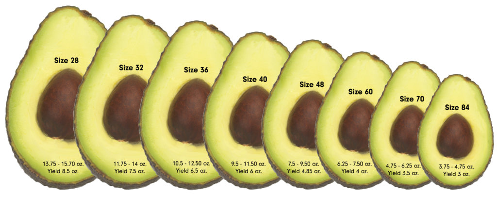

Measurements of avocado sizes ^

- 4046 - Total number of avocados with PLU 4046 sold (Hass Variety, Small Size, Size 60 and smaller)
- 4225 - Total number of avocados with PLU 4225 sold (Hass Variety, Large Size, typically Size 40-48)
- 4770 - Total number of avocados with PLU 4770 sold (Hass Variety, All Sizes, Size 36 and larger)

Since we want to delve into whether or not 2017 could be considered an “Avocadopocalypse,” we had three main research questions:

1. Do the price, volume, and type of avocado change over time?
2. Does the number of avocados sold differ across regions and cities?
3. Is there a preference for certain avocado sizes? Did 2017 change those preferences?

So let’s address the first general question. Was 2017 a statistically significant year for avocado prices? How about for Volume?

The below figure shows the average price and log(Total Volume) of avocado sales, over the 4 years. The key thing to note is that we only used the data that had regions = cities. Any sort of statistical testing done with cities had similar results as regions, as the region data are just aggregated city data. Thus it should be no surprise that we get similar conclusions.

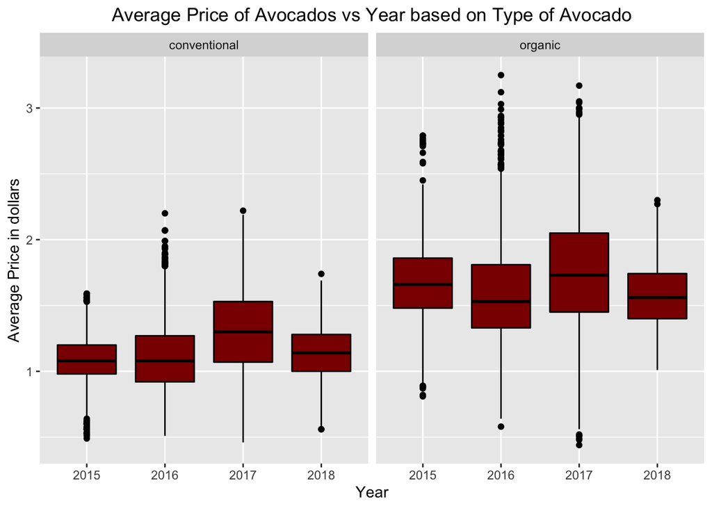

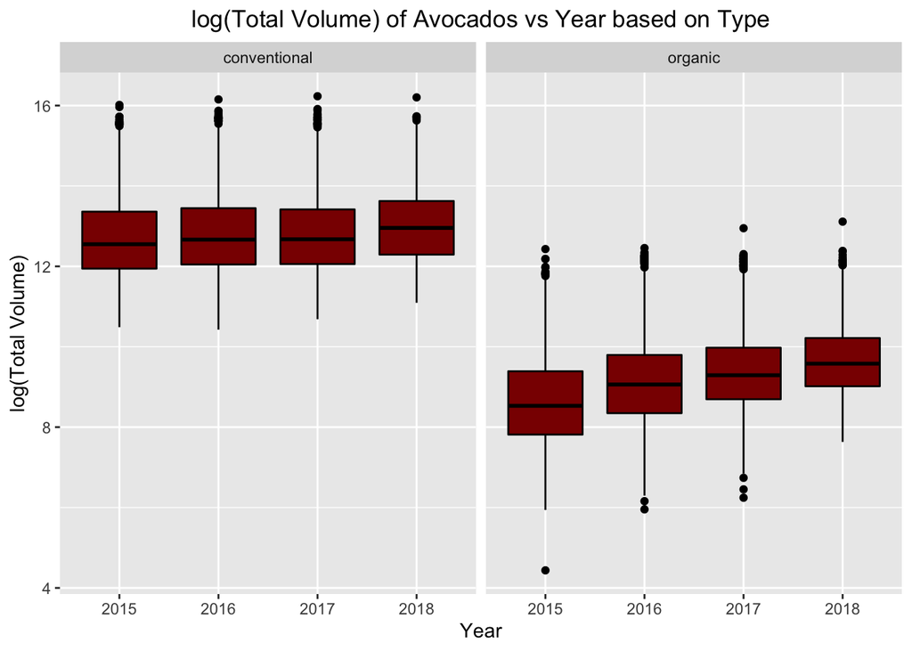

Just from a visualization standpoint, yes for Average Price. We split into two groups because we know traditionally organic goods are more expensive, so we want to control for that. Just to be sure, we ran a t-test to compare the Average Price of conventional vs organic avocados, and found a statistically significant result. No surprises there.

What about within conventional and organic themselves? Do the years differ significantly? We run a bartlett test to determine whether or not variances are equal. We find a significant p-value, thus we ran a Dunnett test with the assumption that the variances are not equal and also find significance: the average price of avocados are not equal between the 4 years, for both conventional and organic avocados.

Main conclusion: For both conventional and organic avocados, 2017 is significant from all other years, when comparing average price.

The dates in our dataset are listed in weekly intervals from 2015-01-04 to 2018-03-25. Each unique data actually has 18249 observations because the dates are repeated for region/city specific information. We decided to create a variation of our dataset where we grouped by unique date (there are 169 unique dates) and calculated the mean average price per date, median total volume per date, standard deviation of average price per date, and standard deviation of median total volume per date. We looked at the mean average price since we found the standard deviations of average price per date to be consistently low (around 0.5), and we looked at the median total volume per date mainly because we found the standard deviations of median total volume per date to be high and varied.

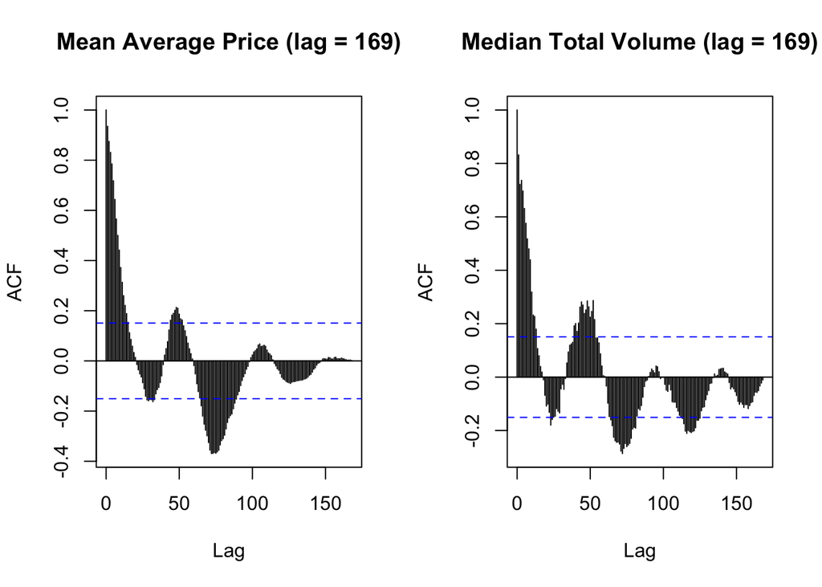

The graph shows that around the start of each year there is a spike in the number of total avocados sold; we could not find any evidence as to why this might be since it appears avocado season starts earliest in March for top-producing states like California. Overall, it appears that the median of total avocados sold per day has been increasing from 2015 to 2018, although we do not see a notable spike in 2017 as we thought we would. In fact, the distribution of avocados sold in 2016 and 2017 look almost the same.

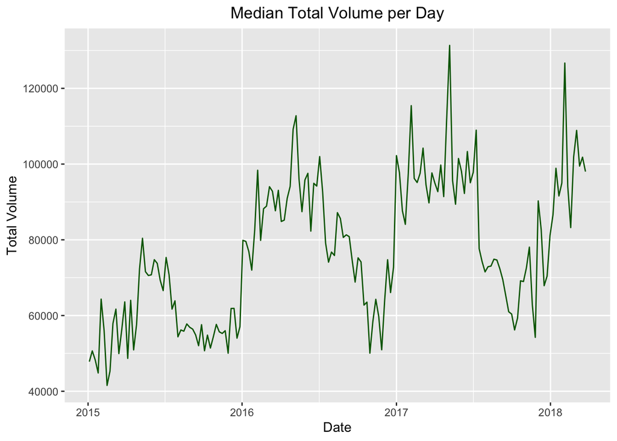

We produced a moving average graph with width 10 to study how avocado price changes in quarterly intervals. It appears that there is a seasonal trend in the pricing of avocados; that is, around summer-time in the U.S. is when prices are highest. The overall prices of avocados increased from 2015 to 2016, and there is a huge spike in price from 2016 to 2017. Interestingly, we look at the previous graph to note that the number of avocados sold from 2016 to 2017 does not change as drastically as the price of avocados from 2016 to 2017.

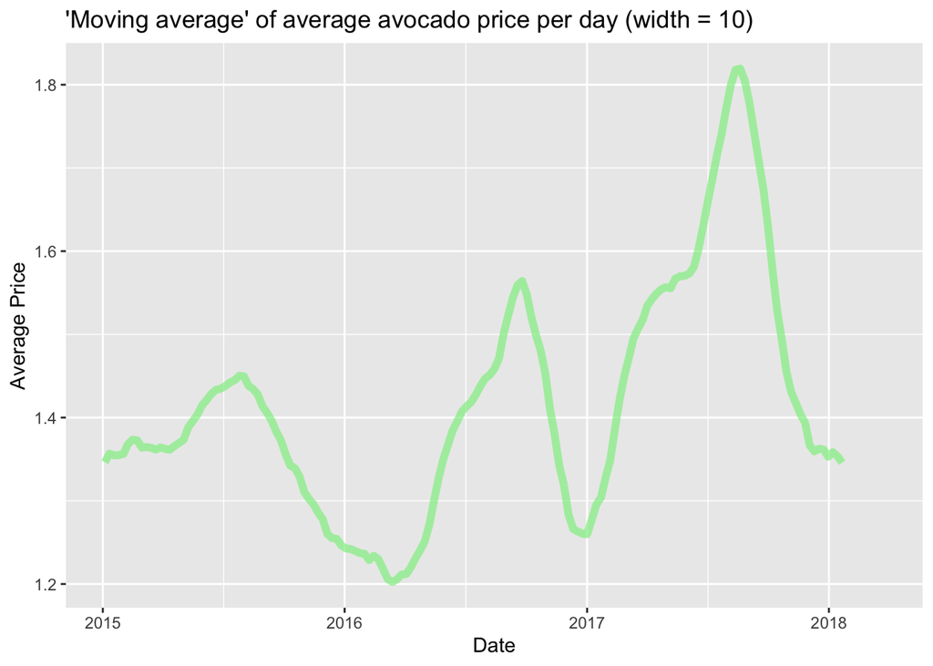

This map shows the difference in avocado prices between 2017 and all other years recorded by region. Each point on the map represents one or two cities included in the dataset. Each coordinate was found using Google Maps. The locations in the dataset that included two cities (e.g. BaltimoreWashington) were placed on the map using a coordinate between the cities. Regions that were not cities that were included in the dataset are not shown on this map. The price difference was found by subtracting the average avocado prices of all years recorded that were not 2017 from the average prices from 2017. The map shows that all cities (except for Pittsburgh, which showed an $0.002 decrease) showed an increase in average price in 2017 compared to other years.

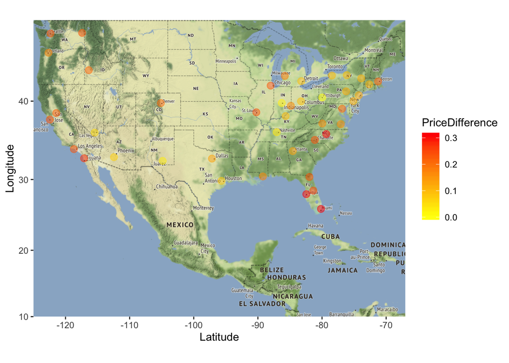

This last graph shows the mean volume of PLUs sold over time. The trends don’t look to be any different for 2017 when compared with any of the other years, for any of the PLUs.

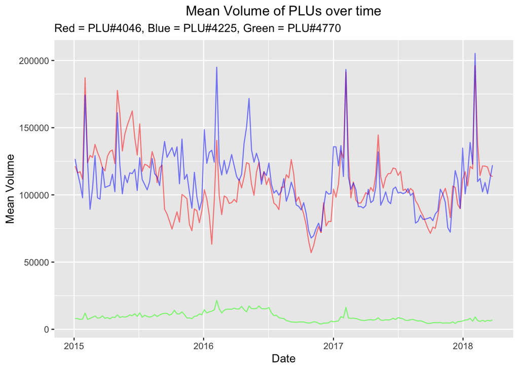

# Conclusion